# Part II - (Effects of employment status, average credit score and recommendations on loan status)

## by (Aratunde Temitayo Samuel)

## Investigation Overview

In this investigation, i want to look at which of the features of a loan could be use to predict its' complete or default status. The main focus will be on `employment status`, `average credit score` and `recommendations count`.

## Dataset Overview

This dataset contains information regarding 113937 prosper loan data which includes loan status and other attributes such as borrower rate (or interest rate), employment status, recommendations count, borrower income, and many others.

The dataset was subset for only values of loan status that includes `Completed, Defaulted or chargedOff` and also for credit score range greater or equals 400.

## Loan Status Distribution

Loan status is a categorical variable and the count plot shows that there are more completed loans in this dataset than there are defaults.

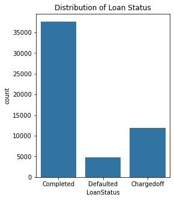

## Distribution of Employment Status

The employment status distribution shows that there are more employed people in our dataset than there are unemployed.

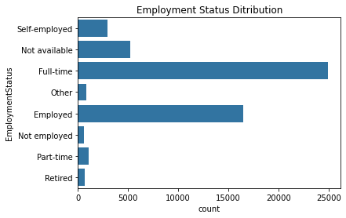

## Distribution of Average Credit Score

The distribution of the average credit score looks slightly normal with most values concentrated between 600 to 800.

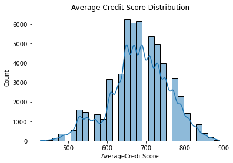

## Recommendation count distribution

This distribution shows that most count fall below 10 with only a few of the values above 10

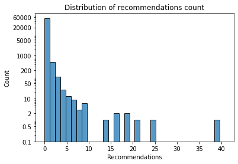

## Loan Status vs Employment Status

Majority of the people granted loans tends to be employed and have verifiable income sources. The following observation can be made based on this distribution.

This suggest that those who are fully employed will be less likely inclined to default than those who are not.

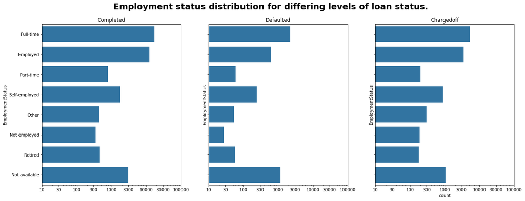

### Loan Status and employment status by average credit score

Those who are fully employed tend to complete their loans. Also those who are fully employed but end up defaulting have lower average credit score than those who completed their loans. Also we can see that the people with the highest chance of defaulting are those who choose `Not available` as their employment status and most of them also have average credit score below 650.

[figure not shown]

### Loan Status and employment status by recommendations count

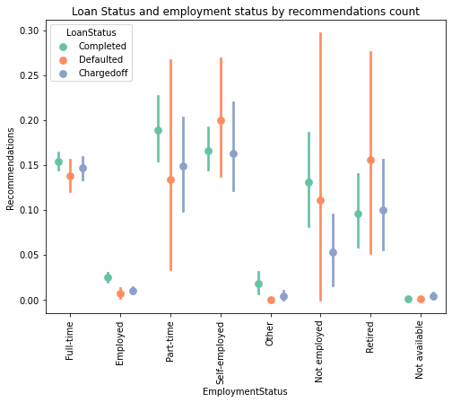